# COVID-19: An Exploratory Data Analysis

Eric Tusa

2024-01-31

```r
library(tidyverse)
library(scales)
library(rvest)
library(usmap)
```

Let’s load the relevant data sets.

```r
# New York Times COVID-19 data sets
us_2020 <- "https://raw.githubusercontent.com/nytimes/covid-19-data/master/us-counties-2020.csv"
us_2021 <- "https://raw.githubusercontent.com/nytimes/covid-19-data/master/us-counties-2021.csv"
us_2022 <- "https://raw.githubusercontent.com/nytimes/covid-19-data/master/us-counties-2022.csv"
us_2023 <- "https://raw.githubusercontent.com/nytimes/covid-19-data/master/us-counties-2023.csv"

# Johns Hopkins CSSEGISandData data sets
csse_global_deaths <- "https://raw.githubusercontent.com/CSSEGISandData/COVID-19/master/csse_covid_19_data/csse_covid_19_time_series/time_series_covid19_deaths_global.csv"
csse_global_cases <- "https://raw.githubusercontent.com/CSSEGISandData/COVID-19/master/csse_covid_19_data/csse_covid_19_time_series/time_series_covid19_confirmed_global.csv"
csse_us_deaths <- "https://raw.githubusercontent.com/CSSEGISandData/COVID-19/master/csse_covid_19_data/csse_covid_19_time_series/time_series_covid19_deaths_US.csv"
csse_us_cases <- "https://raw.githubusercontent.com/CSSEGISandData/COVID-19/master/csse_covid_19_data/csse_covid_19_time_series/time_series_covid19_confirmed_US.csv"

# provided by CU Boulder on Coursera's R Programming Capstone Project course
us_pop_estimates <- "https://raw.githubusercontent.com/2sa2/covid_19_exploratory_data_analysis/main/data/fips_population_estimates.csv"
us_state_pop_estimates <- "https://raw.githubusercontent.com/2sa2/covid_19_exploratory_data_analysis/main/data/NST-EST2023-POP.csv"
global_pop_estimates <- "https://raw.githubusercontent.com/2sa2/covid_19_exploratory_data_analysis/main/data/global_population_estimates.csv"

relevant_files <- c(us_2020, us_2021, us_2022, us_2023, csse_global_deaths, csse_global_cases, csse_us_deaths, csse_us_cases, us_pop_estimates, us_state_pop_estimates, global_pop_estimates)

if(!file.exists("data")) {
  dir.create("data")
}

download_file <- function(file_link) {
  if (!file.exists(file_link)) {
    download.file(file_link, destfile = str_glue("data/{file}", file = basename(file_link)), method = "curl")
  }
}

for (file in relevant_files) {
  if (!file.exists(str_glue("data/{file}", file = basename(file)))) {
    download_file(file)
  }
}
```

Next, we’ll get the data loaded and tidied.

```r
nyt_2020 <- read_csv("data/us-counties-2020.csv")
nyt_2021 <- read_csv("data/us-counties-2021.csv")
nyt_2022 <- read_csv("data/us-counties-2022.csv")
nyt_2023 <- read_csv("data/us-counties-2023.csv")

johns_hopkins_csse_global_deaths <- read_csv("data/time_series_covid19_deaths_global.csv")
johns_hopkins_csse_global_cases <- read_csv("data/time_series_covid19_confirmed_global.csv")
johns_hopkins_csse_us_deaths <- read_csv("data/time_series_covid19_deaths_US.csv")
johns_hopkins_csse_us_cases <- read_csv("data/time_series_covid19_confirmed_US.csv")

us_pop_est <- read_csv("data/fips_population_estimates.csv")
us_state_pop_est <- read_csv("data/NST-EST2023-POP.csv", skip = 3) %>%
  rename(state = ...1) %>% tail(-5) %>%
  filter(!is.na(state)) %>%
  pivot_longer(matches("\\d{4}"), names_to = "year", values_to = "population_est") %>%
  mutate(state = str_remove(state, "."), year = as.integer(year))
global_pop_est <- read_csv("data/global_population_estimates.csv")

# New York Times data
aggregate_nyt_data <- rbind(nyt_2020, nyt_2021, nyt_2022, nyt_2023)

# Johns Hopkins US data
# The idea with pivot_longer() for these data sets is to move columns representing individual dates into one column that represents the date variable
johns_hopkins_csse_us_deaths <- johns_hopkins_csse_us_deaths %>% pivot_longer(matches("\\d{2}"), names_to = "date", values_to = "deaths") %>% mutate(date = as.Date(date,"%m/%d/%y"))
johns_hopkins_csse_us_cases <- johns_hopkins_csse_us_cases %>% pivot_longer(matches("\\d{2}"), names_to = "date", values_to = "cases") %>% mutate(date = as.Date(date, "%m/%d/%y"))
johns_hopkins_csse_us_joined <- johns_hopkins_csse_us_cases %>% left_join(johns_hopkins_csse_us_deaths %>% select(UID, date, deaths),
                                                                          by = join_by(UID, date))
# Johns Hopkins global data
johns_hopkins_csse_global_deaths <- johns_hopkins_csse_global_deaths %>% pivot_longer(matches("\\d{2}"), names_to = "date", values_to = "deaths") %>% mutate(date = as.Date(date,"%m/%d/%y"))
johns_hopkins_csse_global_cases <- johns_hopkins_csse_global_cases %>% pivot_longer(matches("\\d{2}"), names_to = "date", values_to = "cases") %>% mutate(date = as.Date(date,"%m/%d/%y"))
johns_hopkins_csse_global_joined <- johns_hopkins_csse_global_cases %>% left_join(johns_hopkins_csse_global_deaths %>% select(`Province/State`, `Country/Region`, date, deaths), by = join_by(`Province/State`, `Country/Region`, date))
```

# COVID-19: United States

```r
aggregate_nyt_data %>%
  filter(date == max(date)) %>%
  summarise(us_total_cases = sum(cases), us_total_deaths = sum(deaths, na.rm = TRUE)) # Puerto Rico is missing some data for the deaths column
```

```
## # A tibble: 1 × 2
##   us_total_cases us_total_deaths
##            <dbl>           <dbl>
## 1      103910087         1135344
```

Now, let’s break down the total case and death counts by date within the United States.

```r
by_date <- aggregate_nyt_data %>%
  group_by(date) %>%
  summarise(total_cases = sum(cases),
            total_deaths = sum(deaths, na.rm = TRUE))
by_date
```

```
## # A tibble: 1,158 × 3
##    date       total_cases total_deaths
##    <date>           <dbl>        <dbl>
##  1 2020-01-21           1            0
##  2 2020-01-22           1            0
##  3 2020-01-23           1            0
##  4 2020-01-24           2            0
##  5 2020-01-25           3            0
##  6 2020-01-26           5            0
##  7 2020-01-27           5            0
##  8 2020-01-28           5            0
##  9 2020-01-29           5            0
## 10 2020-01-30           6            0
## # ℹ 1,148 more rows
```

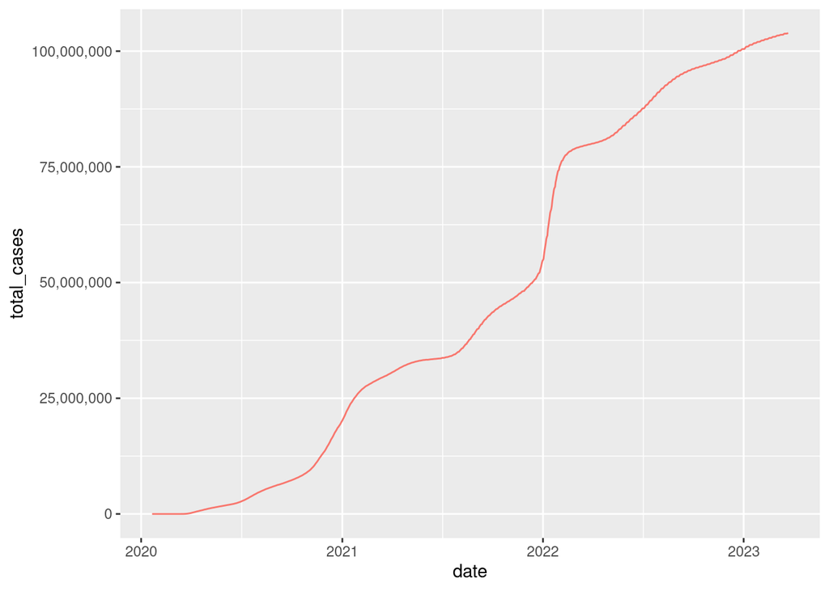

```r
by_date %>% ggplot(aes(x = date)) +
  geom_line(aes(y = total_cases, color = "total_cases")) +
  scale_y_continuous(labels = comma) +
  theme(legend.position = "none")
```

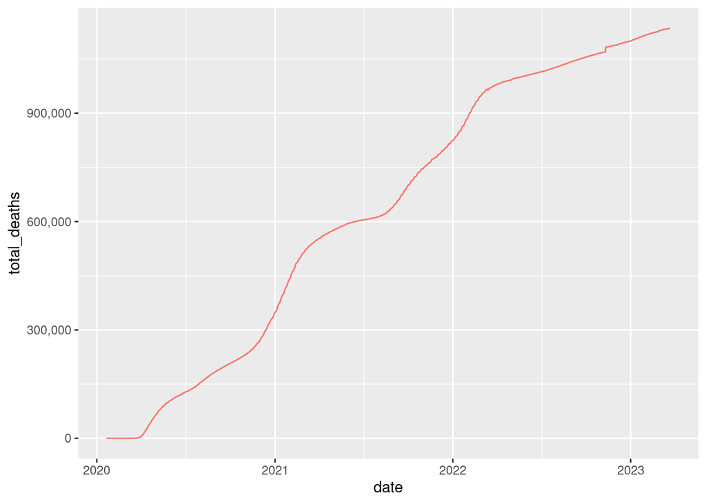

```r
by_date %>% ggplot(aes(x = date)) +
  geom_line(aes(y = total_deaths, color = "total_deaths")) +
  scale_y_continuous(labels = comma) +
  theme(legend.position = "none")
```

One noticeable trend in both of these plots is that both the cases and deaths seem to have sharper increases near the end of both 2020 and 2021 going into the beginning of the following year. As one possible interpretation, this trend could be due to the increased convening of people with their families and friends around the thanksgiving and winter holidays while the virus’s [reproduction number](https://wwwnc.cdc.gov/eid/article/25/1/17-1901_article) was still at a statistically significant level.

In order to get a better understanding of the rate at which the virus was spreading, we can look at the changes in the number of new cases and deaths over time. Let’s first calculate the 1-day changes and the 7-day averages for new cases and deaths, then look at those same statistics per 100,000 people.

*1-day and 7-day averages*

```r
seven_day_avgs <- by_date %>%
  mutate(delta_cases_1 = total_cases - lag(total_cases),
         delta_deaths_1 = total_deaths - lag(total_deaths)) %>%
  mutate(delta_cases_7 = round((delta_cases_1 + lag(delta_cases_1, 1) + lag(delta_cases_1, 2) + lag(delta_cases_1, 3) + lag(delta_cases_1, 4) + lag(delta_cases_1, 5) + lag(delta_cases_1, 6)) / 7, 3),
         delta_deaths_7 = round((delta_deaths_1 + lag(delta_deaths_1, 1) + lag(delta_deaths_1, 2) + lag(delta_deaths_1, 3) + lag(delta_deaths_1, 4) + lag(delta_deaths_1, 5) + lag(delta_deaths_1, 6)) / 7, 3))
seven_day_avgs
```

```
## # A tibble: 1,158 × 7
##    date       total_cases total_deaths delta_cases_1 delta_deaths_1
##    <date>           <dbl>        <dbl>         <dbl>          <dbl>
##  1 2020-01-21           1            0            NA             NA
##  2 2020-01-22           1            0             0              0
##  3 2020-01-23           1            0             0              0
##  4 2020-01-24           2            0             1              0
##  5 2020-01-25           3            0             1              0
##  6 2020-01-26           5            0             2              0
##  7 2020-01-27           5            0             0              0
##  8 2020-01-28           5            0             0              0
##  9 2020-01-29           5            0             0              0
## 10 2020-01-30           6            0             1              0
## # ℹ 1,148 more rows
## # ℹ 2 more variables: delta_cases_7 <dbl>, delta_deaths_7 <dbl>
```

*1-day and 7-day averages per 100,000*

```r
us_pop_est_by_year <- us_pop_est %>% group_by(Year) %>%
  summarise(pop_estimate = sum(Estimate)) %>%
  add_row(Year = c(2022, 2023),
          # manually add population estimates for 2022 and 2023 since fips_population_estimates.csv does not contain data for those years
          #source: https://www.census.gov/popclock/
          pop_estimate = c(334130076, 335888625))
seven_day_avgs_per_100k <- seven_day_avgs %>% mutate(year = year(date)) %>%
  left_join(us_pop_est_by_year, by = join_by(year == Year)) %>% select(-year)

# adds a new column to the input table calculating the input variable per 100,000 people
calculate_per_100000 <- function(table, variable) {
  table %>%
    mutate(
      "{{variable}}" := round({{ variable }} / pop_estimate * 100000, 3)
    )
}

seven_day_avgs_per_100k <- calculate_per_100000(seven_day_avgs_per_100k, total_cases)
seven_day_avgs_per_100k <- calculate_per_100000(seven_day_avgs_per_100k, total_deaths)
seven_day_avgs_per_100k <- calculate_per_100000(seven_day_avgs_per_100k, delta_cases_1)
seven_day_avgs_per_100k <- calculate_per_100000(seven_day_avgs_per_100k, delta_deaths_1)
seven_day_avgs_per_100k <- calculate_per_100000(seven_day_avgs_per_100k, delta_cases_7)
seven_day_avgs_per_100k <- calculate_per_100000(seven_day_avgs_per_100k, delta_deaths_7)

seven_day_avgs_per_100k %>% select(-pop_estimate)
```

```
## # A tibble: 1,158 × 7
##    date       total_cases total_deaths delta_cases_1 delta_deaths_1
##    <date>           <dbl>        <dbl>         <dbl>          <dbl>
##  1 2020-01-21       0                0        NA                 NA
##  2 2020-01-22       0                0         0                  0
##  3 2020-01-23       0                0         0                  0
##  4 2020-01-24       0.001            0         0                  0
##  5 2020-01-25       0.001            0         0                  0
##  6 2020-01-26       0.002            0         0.001              0
##  7 2020-01-27       0.002            0         0                  0
##  8 2020-01-28       0.002            0         0                  0
##  9 2020-01-29       0.002            0         0                  0
## 10 2020-01-30       0.002            0         0                  0
## # ℹ 1,148 more rows
## # ℹ 2 more variables: delta_cases_7 <dbl>, delta_deaths_7 <dbl>
```

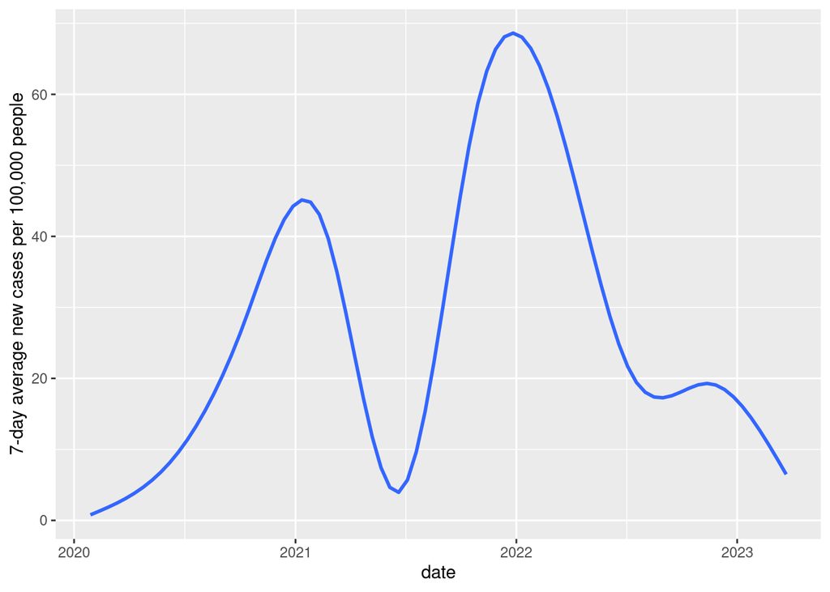

```r
seven_day_avgs_per_100k %>% ggplot(aes(x = date, y = delta_cases_7)) +
  geom_smooth(se = FALSE) +
  ylab("7-day average new cases per 100,000 people")
```

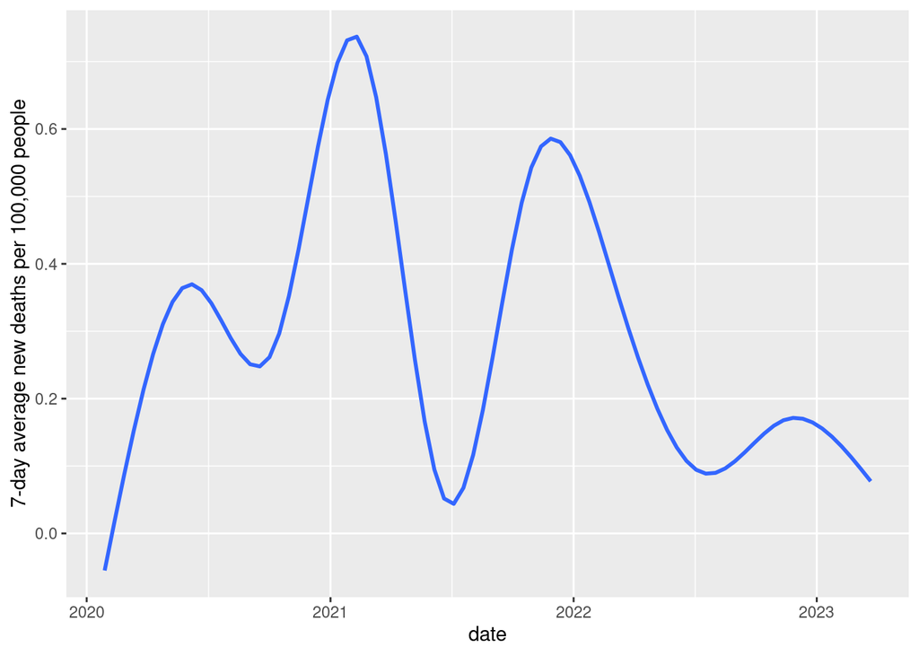

```r
seven_day_avgs_per_100k %>% ggplot(aes(x = date, y = delta_deaths_7)) +
  geom_smooth(se = FALSE) +
  ylab("7-day average new deaths per 100,000 people")
```

Next, I’d like to explore some of the data at the state level. I’ll first look at which states have the highest total cases.

```r
aggregate_nyt_data %>%
  group_by(state, date) %>%
  summarise(cases = sum(cases), deaths = sum(deaths), .groups = "drop") %>%
  filter(date == max(date)) %>%
  arrange(desc(cases))
```

```
## # A tibble: 56 × 4
##    state          date          cases deaths
##    <chr>          <date>        <dbl>  <dbl>
##  1 California     2023-03-23 12169158 104277
##  2 Texas          2023-03-23  8447233  94518
##  3 Florida        2023-03-23  7542869  87141
##  4 New York       2023-03-23  6805271  80109
##  5 Illinois       2023-03-23  4107931  41618
##  6 Pennsylvania   2023-03-23  3539135  50701
##  7 North Carolina 2023-03-23  3481732  29746
##  8 Ohio           2023-03-23  3415254  42061
##  9 Michigan       2023-03-23  3068195  42311
## 10 New Jersey     2023-03-23  3057442  36097
## # ℹ 46 more rows
```

Let’s figure out both cases and deaths per 100,000 people at the state level.

```r
state_data <- aggregate_nyt_data %>%
  # create a new column so joining can be matched on year
  mutate(year = year(date)) %>%
  right_join(us_state_pop_est, by = join_by(state, year)) %>%
  rename(state_pop_est = population_est)

# use weighted averages since 2020 and 2023 don't have data for the full years
year_weights <- as.integer(c(round(difftime("2020-12-31", "2020-01-20")), 365, 365, round(difftime("2023-03-23", "2022-12-31"))))

state_per_100k_by_year <- state_data %>%
  filter(date == "2020-12-31" | date == "2021-12-31" | date == "2022-12-31" | date == max(date)) %>%
  group_by(state, year, state_pop_est) %>%
  summarise(cases = sum(cases),
            deaths = sum(deaths),
            .groups = "drop") %>%
  mutate(cases_yearly = case_when(year == 2020 ~ cases,
                           .default = cases - lag(cases)),
         deaths_yearly = case_when(year == 2020 ~ deaths,
                           .default = deaths - lag(deaths))) %>%
  mutate(cases_yearly_per_100k = round(cases_yearly / state_pop_est * 100000, 3),
         deaths_yearly_per_100k = round(deaths_yearly / state_pop_est * 100000, 3)) %>%
  group_by(state) %>%
  summarise(cases_per_100k = weighted.mean(cases_yearly_per_100k, year_weights),
            deaths_per_100k = weighted.mean(deaths_yearly_per_100k, year_weights)) %>%
  # removing Puerto Rico since it's missing some data for deaths
  filter(state != "Puerto Rico")

state_per_100k_by_year %>% arrange(desc(cases_per_100k))
```

```
## # A tibble: 51 × 3
##    state          cases_per_100k deaths_per_100k
##    <chr>                   <dbl>           <dbl>
##  1 Alaska                 12926.            60.3
##  2 Rhode Island           12751.           107.
##  3 Kentucky               11604.           124.
##  4 North Dakota           11228.            97.9
##  5 West Virginia          11064.           138.
##  6 South Carolina         10677.           117.
##  7 Tennessee              10633.           127.
##  8 New York               10453.           121.
##  9 Florida                10419.           120.
## 10 Wisconsin              10415.            84.2
## # ℹ 41 more rows
```

```r
state_per_100k_by_year %>% arrange(desc(deaths_per_100k))
```

```
## # A tibble: 51 × 3
##    state         cases_per_100k deaths_per_100k
##    <chr>                  <dbl>           <dbl>
##  1 Arizona               10230.            138.
##  2 Mississippi           10188.            138.
##  3 West Virginia         11064.            138.
##  4 Alabama                9796.            131.
##  5 Arkansas              10172.            131.
##  6 New Mexico             9757.            131.
##  7 Michigan               9329.            127.
##  8 Tennessee             10633.            127.
##  9 Oklahoma               9816.            126.
## 10 Kentucky              11604.            124.
## # ℹ 41 more rows
```

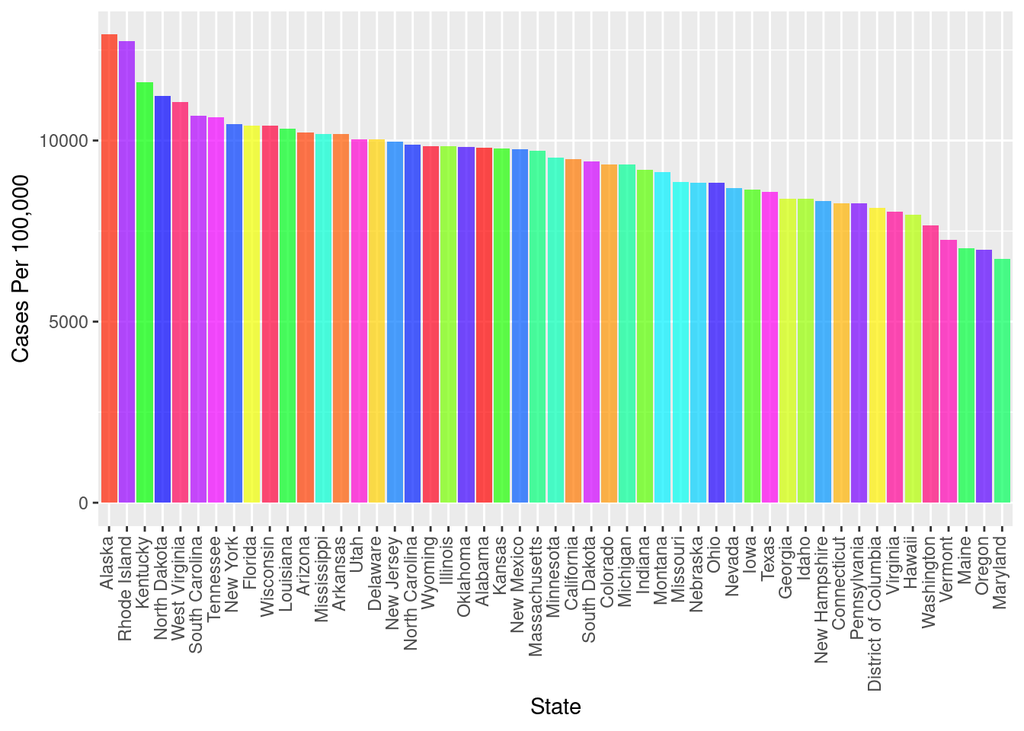

```r
state_colors <- setNames(rainbow(n = n_distinct(state_per_100k_by_year$state), alpha = 0.7), unique(state_per_100k_by_year$state))
state_per_100k_by_year %>% ggplot(aes(x = reorder(state, -cases_per_100k), y = cases_per_100k, fill = state)) +
  geom_col(stat = "identity", position = "dodge") +
  scale_fill_manual(values = state_colors) +
  labs(x = "State", y = "Cases Per 100,000") +
  theme(legend.position = "none", axis.text.x = element_text(angle = 90, hjust = 1, vjust = 0.3))
```

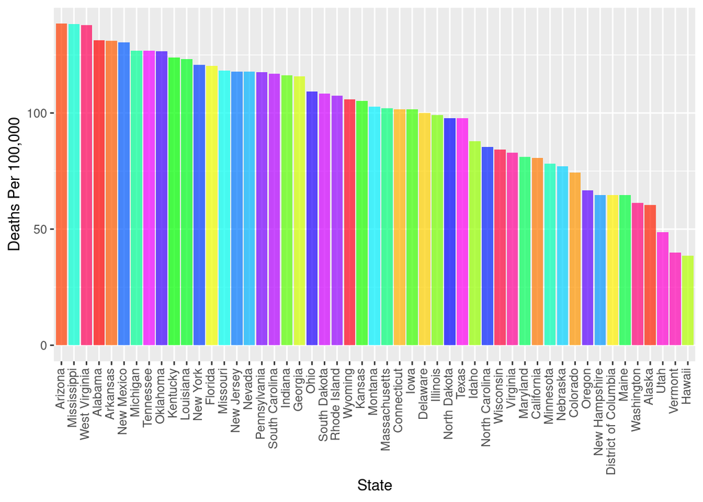

```r
state_per_100k_by_year %>% ggplot(aes(x = reorder(state, -deaths_per_100k), y = deaths_per_100k, fill = state)) +
  geom_col(stat = "identity", position = "dodge") +
  scale_fill_manual(values = state_colors) +
  labs(x = "State", y = "Deaths Per 100,000") +
  theme(legend.position = "none", axis.text.x = element_text(angle = 90, hjust = 1, vjust = 0.3))
```

I see a trend in the top 10 states in both the cases and deaths per 100,000 in terms of political party control within each respective state. Let’s look into it further in terms of deaths.

```r
wiki_state_political_party_strength <- read_html("https://en.wikipedia.org/wiki/Political_party_strength_in_U.S._states")
tables <- wiki_state_political_party_strength %>% html_table(fill = TRUE)
party_strength <- tables[[3]] %>% filter(State %in% head(arrange(state_per_100k_by_year, desc(deaths_per_100k)), 10)$state) %>%
  summarise(dem_presidential_2020 = sum(`2020 presidentialelection` == "Democratic"),
            rep_presidendial_2020 = sum(`2020 presidentialelection` == "Republican"),
            dem_governor = sum(Governor == "Democratic"),
            rep_governor = sum(Governor == "Republican"))
party_strength
```

```
## # A tibble: 1 × 4
##   dem_presidential_2020 rep_presidendial_2020 dem_governor rep_governor
##                   <int>                 <int>        <int>        <int>
## 1                     3                     7            4            6
```

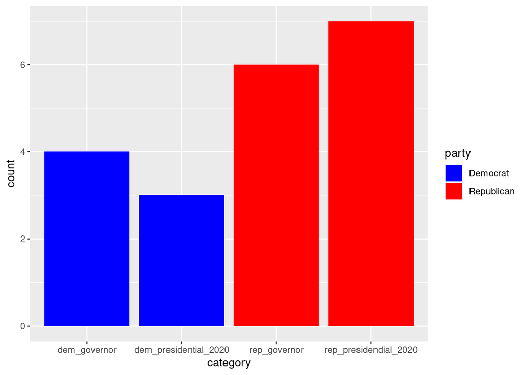

```r
party_strength %>% pivot_longer(everything(), names_to = "category", values_to = "count") %>%
  mutate(party = if_else(str_starts(category, "dem"), "Democrat", "Republican")) %>%
  ggplot(aes(x = category, y = count, fill = party)) +
  geom_col() +
  scale_fill_manual(values = c("Democrat" = "blue", "Republican" = "red"))
```

As we can see from these bar charts, the top 10 states in terms of deaths per 100,000 people tended to vote Republican for recent presidential and gubernatorial elections, and that there exists some sort of positive correlation between generally Republican-voting states and a higher likelihood of negative outcomes in terms of COVID-19. While some may think this correlation is obvious based on their personal experiences these last few years and with the ongoing news coverage surrounding COVID-19, being able to pull the data and create visualizations that can either begin to confirm or challenge those conclusions can help to guide further research and ultimately shape future policy to strive for better outcomes when faced with these sort of challenges like COVID-19.

### Minnesota

Now, I’d like to look at some of the data for my home state of Minnesota. Let’s look at the 7-day averages for cases and deaths.

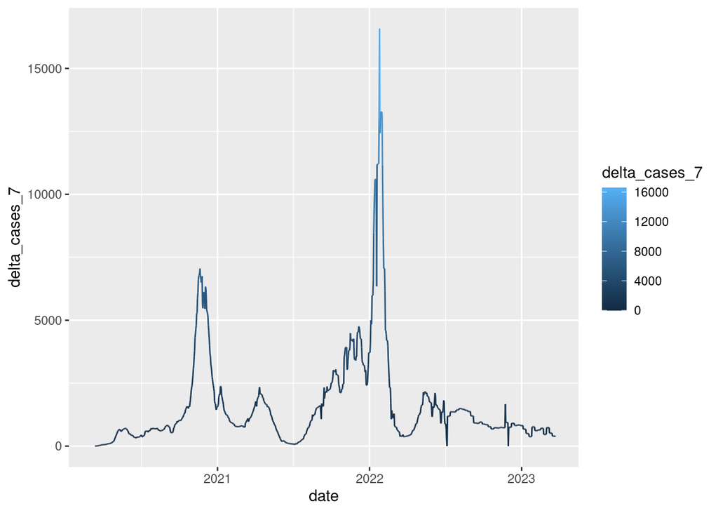

```r
mn <- state_data %>%
  filter(state == "Minnesota") %>%
  group_by(date, state, state_pop_est) %>%
  summarise(cases = sum(cases),
            deaths = sum(deaths),
            .groups = "drop") %>%
  mutate(delta_cases_1 = cases - lag(cases),
         delta_deaths_1 = deaths - lag(deaths),
         delta_cases_7 = round((delta_cases_1 + lag(delta_cases_1, 1) + lag(delta_cases_1, 2) + lag(delta_cases_1, 3) + lag(delta_cases_1, 4) + lag(delta_cases_1, 5) + lag(delta_cases_1, 6)) / 7, 3),
         delta_deaths_7 = round((delta_deaths_1 + lag(delta_deaths_1, 1) + lag(delta_deaths_1, 2) + lag(delta_deaths_1, 3) + lag(delta_deaths_1, 4) + lag(delta_deaths_1, 5) + lag(delta_deaths_1, 6)) / 7, 3))

mn %>% ggplot(aes(x = date, y = delta_cases_7, color = delta_cases_7)) +
  geom_line()
```

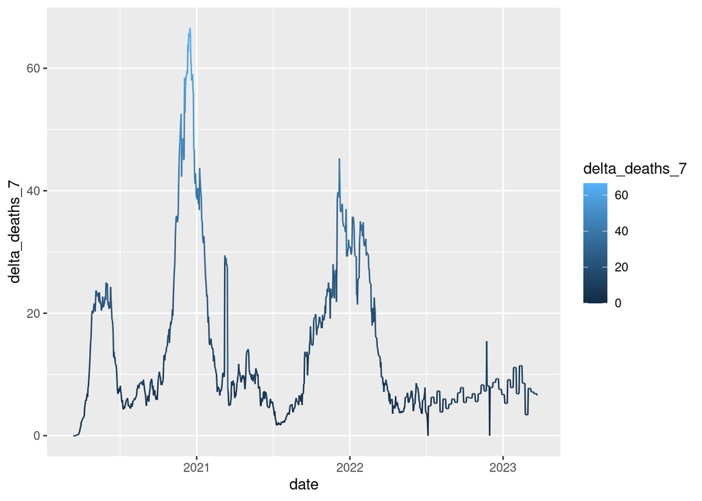

```r
mn %>% ggplot(aes(x = date, y = delta_deaths_7, color = delta_deaths_7)) +
  geom_line()
```

Looking at the two spikes in 7-day average cases near the end of 2020 and the beginning of 2022 and comparing those time periods that correspond in the 7-day average deaths chart, I see that there was a relatively large spike in deaths following the 2020 spike in 7-day average cases. However, the spike in 7-day average cases at the beginning of 2022 was relatively larger than the spike at the end of 2020, but had a significantly smaller spike in 7-day average deaths compared to the spike in deaths at the end of 2020. My intuition tells me that Minnesota was better prepared for the 2022 spike, which resulted in relatively fewer deaths. It may be worth doing further research to discover what exactly Minnesota did to become better prepared.

```r
mn <- state_data %>%
  filter(state == "Minnesota" & date == max(date)) %>%
  mutate(fips = as.numeric(fips)) %>%
  group_by(county, fips, date) %>%
  summarise(cases = sum(cases),
            deaths = sum(deaths),
            .groups = "drop") %>%
  left_join(us_pop_est %>%
              filter(Year == 2021) %>%
              select(fips, Estimate), by = join_by(fips)) %>%
  rename(pop_est_2021 = Estimate)
mn
```

```
## # A tibble: 88 × 6
##    county      fips date        cases deaths pop_est_2021
##    <chr>      <dbl> <date>      <dbl>  <dbl>        <dbl>
##  1 Aitkin     27001 2023-03-23   3730     65        15887
##  2 Anoka      27003 2023-03-23 119732    888       367018
##  3 Becker     27005 2023-03-23  10555    102        35219
##  4 Beltrami   27007 2023-03-23  14444    141        46380
##  5 Benton     27009 2023-03-23  17117    203        41459
##  6 Big Stone  27011 2023-03-23   1786     14         5145
##  7 Blue Earth 27013 2023-03-23  21485    128        69280
##  8 Brown      27015 2023-03-23   8047     90        25819
##  9 Carlton    27017 2023-03-23  11498    124        36409
## 10 Carver     27019 2023-03-23  32130    145       108626
## # ℹ 78 more rows
```

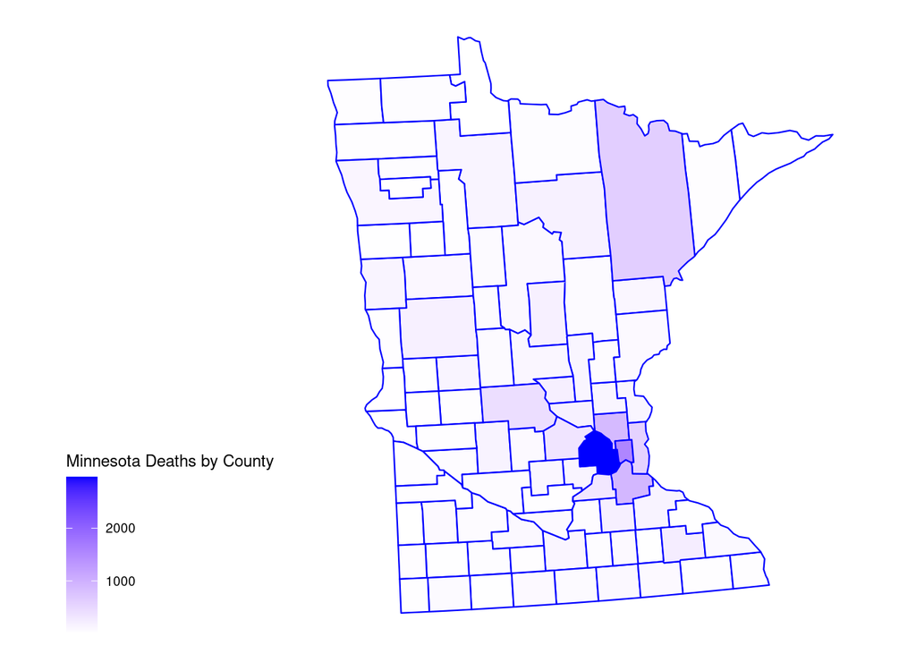

```r
plot_usmap(regions = "county", include = "MN", data = mn, values = "deaths", color = "blue") +
  scale_fill_continuous(low = "white", high = "blue", name = "Minnesota Deaths by County") +
  theme(legend.position = "left")
```

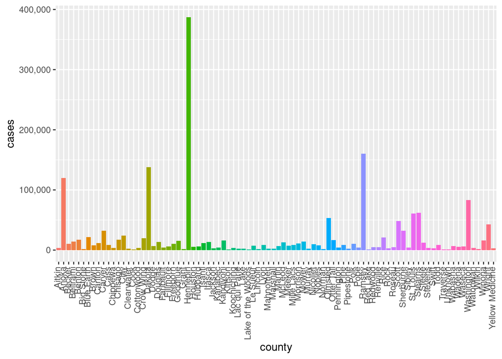

```r
mn %>% ggplot(aes(x = county, y = cases, fill = county)) +
  geom_col() +
  scale_y_continuous(labels = comma) +
  theme(legend.position = "none", axis.text.x = element_text(angle = 90, hjust = 1, vjust = 0.3))
```

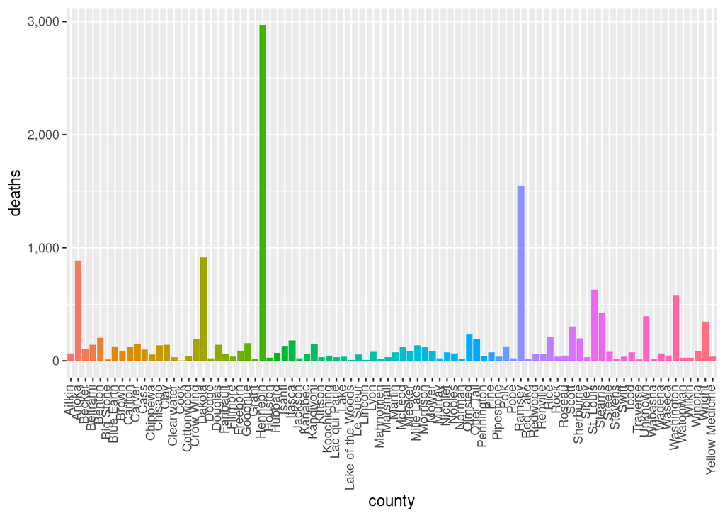

```r
mn %>% ggplot(aes(x = county, y = deaths, fill = county)) +
  geom_col() +
  scale_y_continuous(labels = comma) +
  theme(legend.position = "none", axis.text.x = element_text(angle = 90, hjust = 1, vjust = 0.3))
```

It looks like the more densely populated counties have higher case and death counts, and the less densely populated counties have lower case and death counts. I think that’s pretty intuitive, but it’s still nice to see it in a chart.

# COVID-19: World

Let’s now take a look at some global COVID-19 data. I’d like to first compare the US NYT data to the US Johns Hopkins data.

```r
jh_us <- johns_hopkins_csse_us_cases %>%
  group_by(date) %>%
  summarise(cases = sum(cases)) %>%
  inner_join(johns_hopkins_csse_us_deaths %>%
               group_by(date) %>%
               summarise(deaths = sum(deaths)), by = join_by(date))

jh_us
```

```
## # A tibble: 1,143 × 3
##    date       cases deaths
##    <date>     <dbl>  <dbl>
##  1 2020-01-22     1      1
##  2 2020-01-23     1      1
##  3 2020-01-24     2      1
##  4 2020-01-25     2      1
##  5 2020-01-26     5      1
##  6 2020-01-27     5      1
##  7 2020-01-28     5      1
##  8 2020-01-29     6      1
##  9 2020-01-30     6      1
## 10 2020-01-31     8      1
## # ℹ 1,133 more rows
```

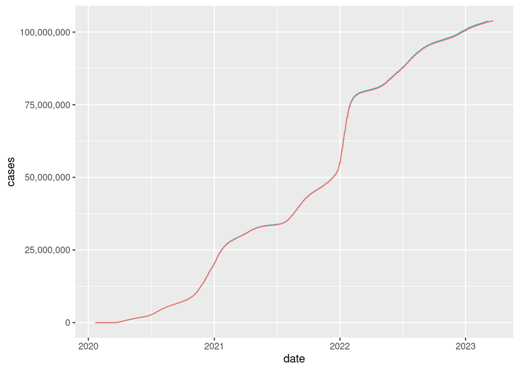

```r
jh_us %>% ggplot(aes(x = date, y = cases, color = "red")) +
  geom_line() +
  geom_line(data = by_date, aes(x = date, y = total_cases, color = "blue")) +
  scale_y_continuous(labels = comma) +
  theme(legend.position = "none")
```

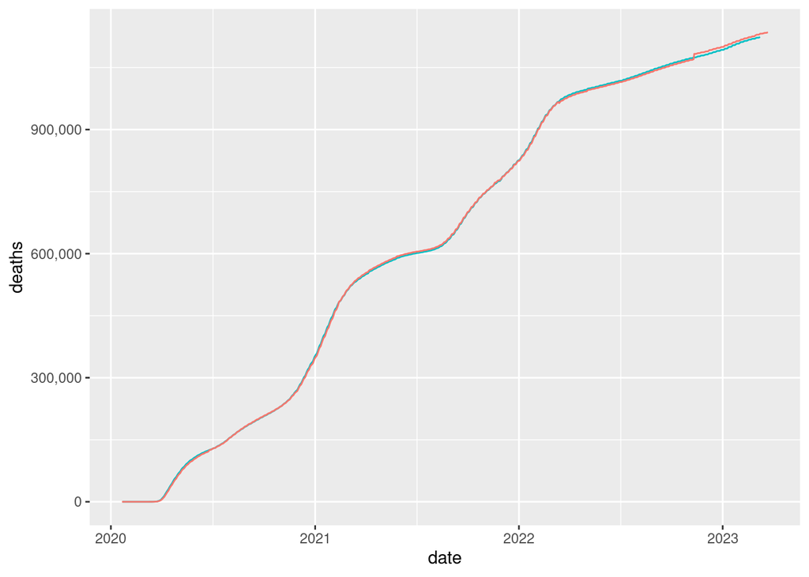

```r
jh_us %>% ggplot(aes(x = date, y = deaths, color = "red")) +
  geom_line() +
  geom_line(data = by_date, aes(x = date, y = total_deaths, color = "blue")) +
  scale_y_continuous(labels = comma) +
  theme(legend.position = "none")
```

As we can see from these line charts, the NYT and Johns Hopkins data is generally similar in terms of cases and deaths over time. Any discrepancies could likely be attributed to a combination of data collection technique, unreported, underreported, or overreported cases and/or deaths, and/or errors in data entry.

Finally, I’d like to get a quick overview of global COVID-19 case and death rates. In order to do this, I’ll have to first do some more tidying of the data.

```r
global_pop_est <- global_pop_est %>%
  pivot_longer(matches("\\d"), names_to = "year", names_pattern = "^(....).*", values_to = "population") %>%
  mutate(year = as.integer(year), population = as.numeric(population)) %>%
  filter(year == 2021)

overview <- johns_hopkins_csse_global_joined %>%
  mutate(Country_Region = case_when(`Country/Region` == "Congo (Brazzaville)" ~ "Congo, Dem. Rep.",
                                    `Country/Region` == "Congo (Kinshasa)" ~ "Congo, Rep.",
                                    `Country/Region` == "Bahamas" ~ "Bahamas, The",
                                    `Country/Region` == "Brunei" ~ "Brunei Darussalam",
                                    `Country/Region` == "Burma" ~ "Myanmar",
                                    `Country/Region` == "Czechia" ~ "Czech Republic",
                                    `Country/Region` == "Egypt" ~ "Egypt, Arab Rep.",
                                    `Country/Region` == "Gambia" ~ "Gambia, The",
                                    `Country/Region` == "Iran" ~ "Iran, Islamic Rep.",
                                    `Country/Region` == "Korea, North" ~ "Korea, Dem. People's Rep.",
                                    `Country/Region` == "Korea, South" ~ "Korea, Rep.",
                                    `Country/Region` == "Kyrgyzstan" ~ "Kyrgyz Republic",
                                    `Country/Region` == "Laos" ~ "Lao PDR",
                                    `Country/Region` == "Micronesia" ~ "Micronesia, Fed. Sts.",
                                    `Country/Region` == "Russia" ~ "Russian Federation",
                                    `Country/Region` == "Saint Kitts and Nevis" ~ "St. Kitts and Nevis",
                                    `Country/Region` == "Saint Lucia" ~ "St. Lucia",
                                    `Country/Region` == "Saint Vincent and the Grenadines" ~ "St. Vincent and the Grenadines",
                                    `Country/Region` == "Slovakia" ~ "Slovak Republic",
                                    `Country/Region` == "Syria" ~ "Syrian Arab Republic",
                                    `Country/Region` == "US" ~ "United States",
                                    `Country/Region` == "Venezuela" ~ "Venezuela, RB",
                                    `Country/Region` == "Yemen" ~ "Yemen, Rep.",
                                    .default = `Country/Region`)) %>%
  left_join(global_pop_est %>% select(`Country Name`, year, population), by = join_by(Country_Region == `Country Name`))

overview <- overview %>%
  mutate(population = case_when(Country_Region == "Taiwan*" ~ 23570000, # from Wikipedia
                                .default = population)) %>%
  filter(date == max(date)) %>%
  group_by(Country_Region, population) %>%
  summarise(cases = sum(cases),
            deaths = sum(deaths)) %>%
  ungroup() %>%
  mutate(cases_100k = round(cases / population * 100000, 3), deaths_100k = round(deaths / population * 100000, 3))

overview
```

```
## # A tibble: 201 × 6
##    Country_Region      population    cases deaths cases_100k deaths_100k
##    <chr>                    <dbl>    <dbl>  <dbl>      <dbl>       <dbl>
##  1 Afghanistan           39835000   209451   7896       526.       19.8
##  2 Albania                2832000   334457   3598     11810.      127.
##  3 Algeria               44617000   271496   6881       609.       15.4
##  4 Andorra                  77000    47890    165     62195.      214.
##  5 Angola                33934000   105288   1933       310.        5.70
##  6 Antarctica                  NA       11      0        NA        NA
##  7 Antigua and Barbuda      99000     9106    146      9198.      147.
##  8 Argentina             45784000 10044957 130472     21940.      285.
##  9 Armenia                2968000   447308   8727     15071.      294.
## 10 Australia             25973000 11399460  19574     43890.       75.4
## # ℹ 191 more rows
```

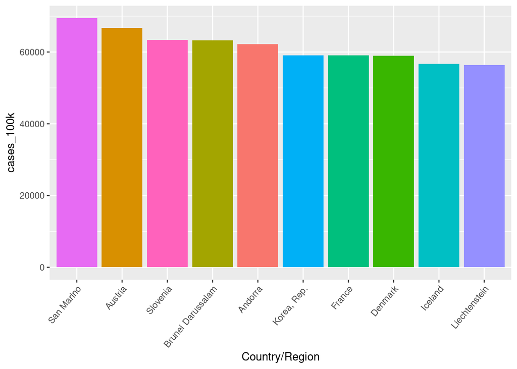

```r
overview %>% arrange(desc(cases_100k)) %>% head(10) %>% ggplot(aes(x = reorder(Country_Region, -cases_100k), y = cases_100k, fill = Country_Region)) +
  geom_col(stat = "identity") +
  labs(x = "Country/Region") +
  theme(legend.position = "none", axis.text.x = element_text(angle = 50, hjust = 1))
```

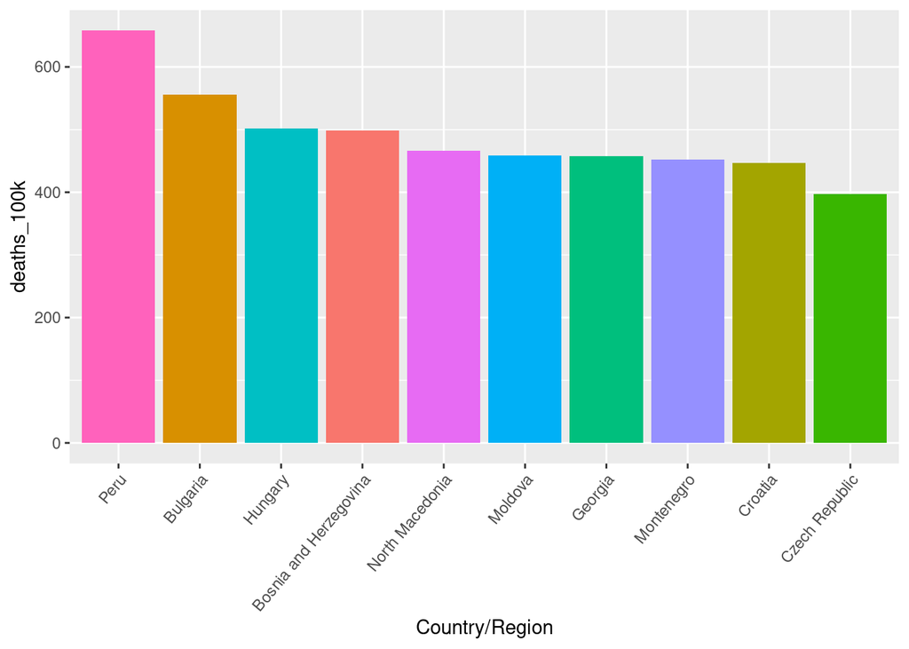

```r
overview %>% arrange(desc(deaths_100k)) %>% head(10) %>% ggplot(aes(x = reorder(Country_Region, -deaths_100k), y = deaths_100k, fill = Country_Region)) +
  geom_col(stat = "identity") +
  labs(x = "Country/Region") +
  theme(legend.position = "none", axis.text.x = element_text(angle = 50, hjust = 1))
```

It looks like Peru has the highest COVID-19 death rate, which seems surprising at first glance. However, with a little more research on the internet, one can discover that Peru’s healthcare system is pretty abysmal compared to the rest of the world.

# Conclusion

The COVID-19 pandemic put a lot of strain on the world and disproportionately affected certain areas more than other areas due to a number of socioeconomic factors, including but not limited to local, state, and country-level government policy, existing issues in a given area’s healthcare system, and funding available in a given area. There may exist some bias in the data sets I used here, as it is possible that COVID-19 cases may have been underreported or overreported, either willfully or negligently, in some areas of the world. There is much more research that could be done, as I have only scratched the surface in this analysis.